# MP2

2024-10-26

```r
library(readxl)
library(forecast)
```

```r
library(tseries)
library(TTR)
library(ggplot2)
library(tidyr)
library(dplyr)
insurance <- read.csv("/Users/kiannazem/Downloads/insurance.csv")
```

```r
insurance_ts <- ts(insurance$Quotes, start=c(2002, 01), end=c(2005,04),frequency=12)
```

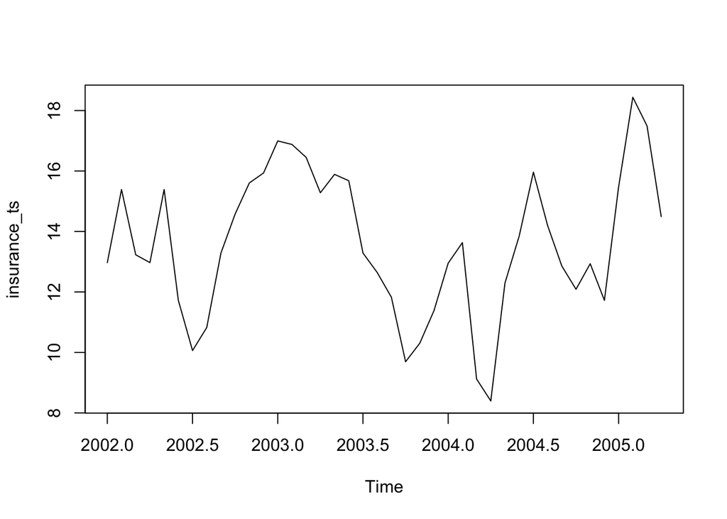

```r
plot(insurance_ts)
```

Hypothesis: There does not seem to be any clear trends or seasonality based on the time series plot.

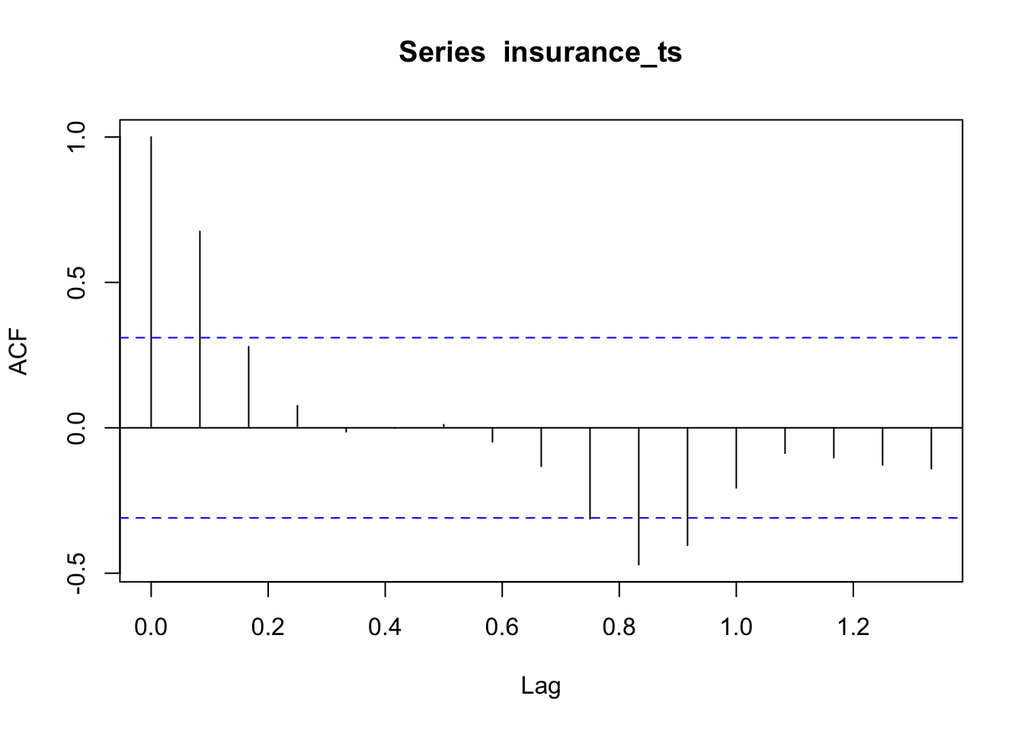

```r
acf(insurance_ts)
```

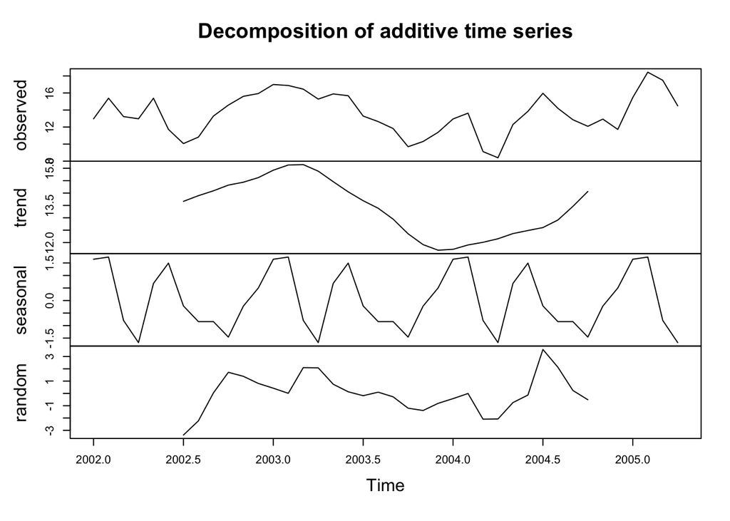

```r
additive_decomp <- decompose(insurance_ts, type="additive")
plot(additive_decomp)
```

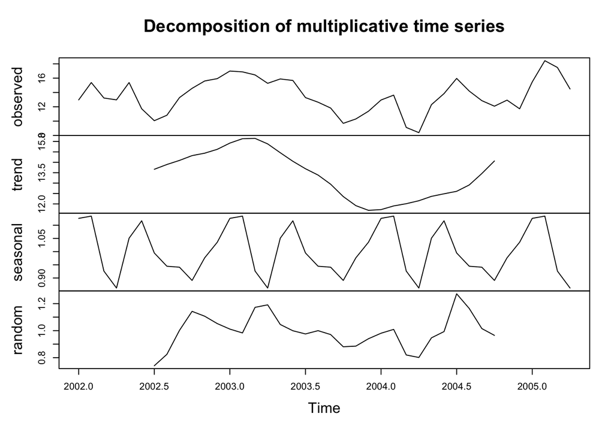

```r
multiplicative_decomp <- decompose(insurance_ts, type="multiplicative")
plot(multiplicative_decomp)
```

the ACF and Decomposition tell us that there is no strong trend or seasonality. There does seem to be some trend in the upward direction in the most recent data points and also a seasonal aspect, although it’s not very strong.

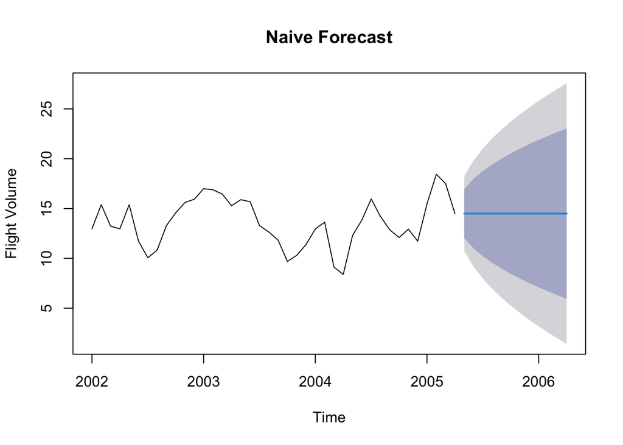

```r
naive_forecast <- naive(insurance_ts, h=12)
plot(naive_forecast, main="Naive Forecast", ylab="Flight Volume", xlab="Time")
```

The Naive model assumes that future values will be the same as the most recent value. This is just a simple straight line for a forecast.

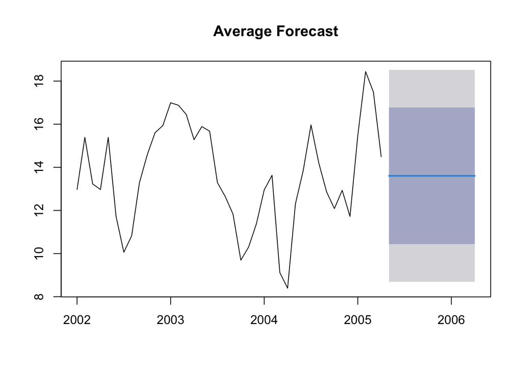

```r
average_forecast <- meanf(insurance_ts, h=12)
plot(average_forecast, main="Average Forecast")
```

The Average model assumes that future values will be equal to the historical average.

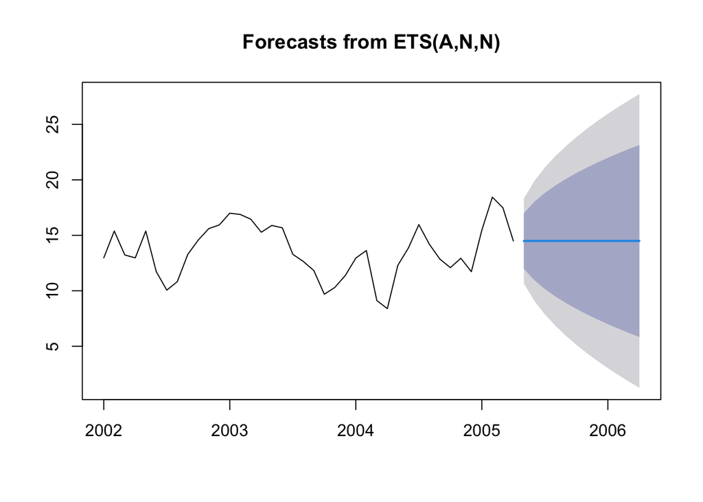

```r
ets_model <- ets(insurance_ts)
ets_forecast <- forecast(ets_model, h=12)
plot(ets_forecast)
```

ETS handles both trend and seasonality and adapts to changes in the data. There doesn’t seem to be much seasonality however, so I don’t believe that the difference in accuracy between the ETS andthe naive model for example will be much. It actually looks really quite similar to the naive model.

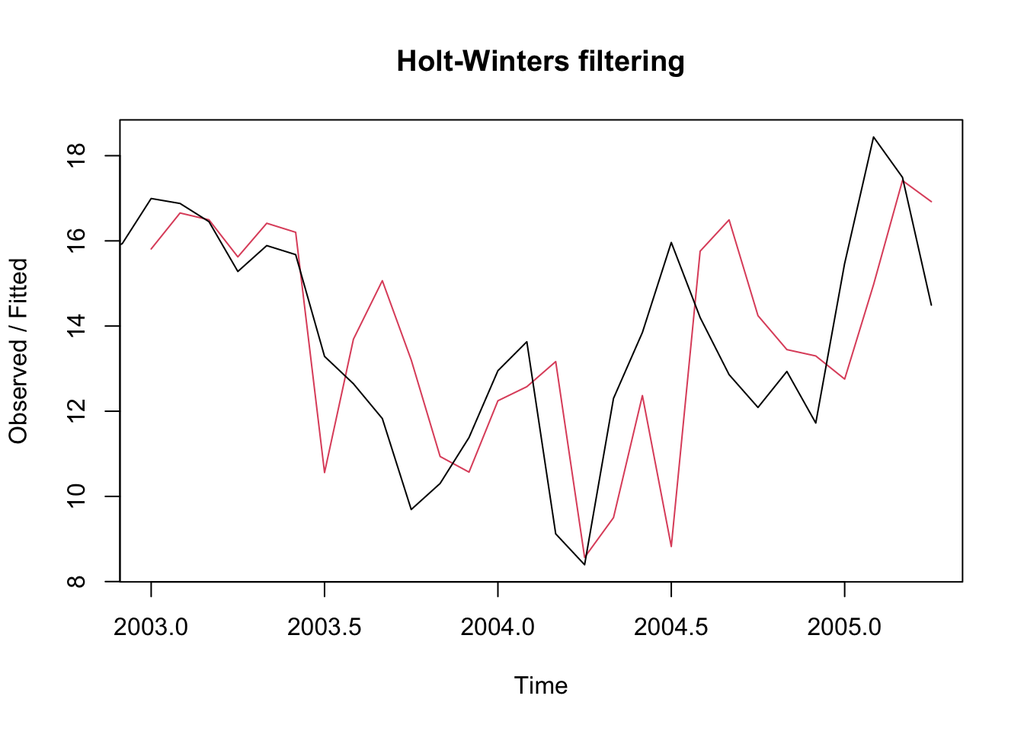

```r
hw_forecast <- HoltWinters(insurance_ts)
plot(hw_forecast)
```

The Holt-Winters model is useful when the data has strong seasonal patterns and trends. In this case, there isn’t much of a strong trend or seasonality aspect, which is why I believe comparing the RMSEs will show that the Holt-Winters method will not be the best forecasting model for this particular dataset.

```r
accuracy_naive <- accuracy(naive_forecast)
accuracy_avg <- accuracy(average_forecast)
accuracy_ets <- accuracy(ets_forecast)
accuracy_hw <- accuracy(forecast(hw_forecast))
```

```r
str(accuracy_naive)
```

```
##  num [1, 1:7] 0.039 1.924 1.573 -0.873 12.16 ...
##  - attr(*, "dimnames")=List of 2
##   ..$ : chr "Training set"
##   ..$ : chr [1:7] "ME" "RMSE" "MAE" "MPE" ...
```

```r
print(paste("RMSE (Naive):", accuracy_naive[2]))
```

```
## [1] "RMSE (Naive): 1.92432585375589"
```

```r
print(paste("RMSE (Average):", accuracy_avg[2]))
```

```
## [1] "RMSE (Average): 2.36916526673341"
```

```r
print(paste("RMSE (ETS):", accuracy_ets[2]))
```

```
## [1] "RMSE (ETS): 1.90013955378115"
```

```r
print(paste("RMSE (Holt-Winters):", accuracy_hw[2]))
```

```
## [1] "RMSE (Holt-Winters): 2.40440521467202"
```

The lower RMSE of the exponential smoothing model tells me that it’s a better, more accurate model, than the other models for this particular dataset. The Naive model also has quite a low RMSE which tells me that this perhaps isn’t that complicated of a dataset. I believe it goes back to the point I got from the ACF and decompostion which didn’t really show much trend or seasonality, although there was some of that. ETS adjusts to the changes in patterns though, making it more reliable for future forecasting when there’s both seasonality and trends even though it’s not much.

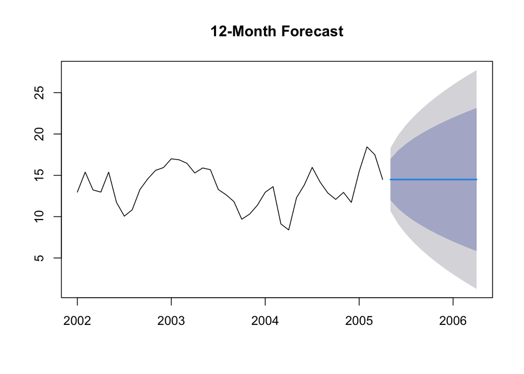

```r
forecast_12_months <- forecast(ets_model, h=12)
plot(forecast_12_months, main="12-Month Forecast")
```

```r
forecast(ets_forecast, h=12)
```

```
##          Point Forecast     Lo 80    Hi 80     Lo 95    Hi 95
## May 2005       14.49198 11.993593 16.99037 10.671026 18.31293
## Jun 2005       14.49198 10.958903 18.02506  9.088606 19.89535
## Jul 2005       14.49198 10.164935 18.81903  7.874335 21.10962
## Aug 2005       14.49198  9.495580 19.48838  6.850646 22.13331
## Sep 2005       14.49198  8.905863 20.07810  5.948751 23.03521
## Oct 2005       14.49198  8.372716 20.61124  5.133373 23.85059
## Nov 2005       14.49198  7.882435 21.10153  4.383553 24.60041
## Dec 2005       14.49198  7.426092 21.55787  3.685637 25.29832
## Jan 2006       14.49198  6.997484 21.98648  3.030138 25.95382
## Feb 2006       14.49198  6.592097 22.39186  2.410151 26.57381
## Mar 2006       14.49198  6.206520 22.77744  1.820462 27.16350
## Apr 2006       14.49198  5.838106 23.14585  1.257021 27.72694
```